# Immigration and Wages in the USA: A State-Level Exploratory Analysis.

Jennifer

2026-04-29

## Motivation

Immigration has been one of the most debated economic and political issues in the United States. Labor economists have long studied whether immigration complements or competes with native workers (Borjas 1987; Card 1990; Peri 2012). The empirical evidence is complicated because immigrants are not randomly distributed across locations — they tend to move to high-wage, high-opportunity areas, creating a selection problem. The inclusion of multiple decades of data allows for the examination of changes in immigration patterns over time, including the role of major policy shifts.

## Research Question

(Causal) Does a higher immigrant share in a state cause wages to increase or decrease for workers in that state? This question matters because immigration policy affects millions and should be guided by solid evidence on labor market impacts. The immigrant share of the U.S. workforce rose from 9.4% in 2000 to 13.7% in 2020, alongside changes in wage inequality, yet economists still disagree on the effect on wages. Montana provides a useful contrast with a low immigrant share (3.5% in 2020), compared to high-immigration states like California (46.5%) and New York (38.3%). Comparing these regions helps assess whether higher immigration is associated with higher wages—and whether the relationship is causal or coincidental, informing policy debates in both high- and low-immigration areas.

## Research Question Type: Why This Is a Causal Question

This study asks a causal question, whether changes in immigrant share cause changes in wages—rather than a descriptive or predictive one. A descriptive approach would only measure correlation between immigration and wages, without explaining causation. A predictive approach would focus on forecasting wages using any correlated variables, regardless of their economic meaning. In contrast, this analysis aims to identify the true causal effect, which is essential for policy decisions. To do this, it isolates variation in immigrant share that is unrelated to wage determinants, using a shift-share instrumental variable.

```
## Rows: 153
## Columns: 14
## $ state_fips      <dbl> 1, 1, 1, 2, 2, 2, 4, 4, 4, 5, 5, 5, 6, 6, 6, 8, 8, 8, …
## $ state_abb       <chr> "AL", "AL", "AL", "AK", "AK", "AK", "AZ", "AZ", "AZ", …
## $ state_name      <chr> "Alabama", "Alabama", "Alabama", "Alaska", "Alaska", "…
## $ year            <dbl> 2000, 2010, 2020, 2000, 2010, 2020, 2000, 2010, 2020, …
## $ n_obs           <dbl> 174, 119, 182, 136, 140, 116, 176, 117, 146, 144, 74, …
## $ n_weighted      <dbl> 397663.90, 265924.63, 292399.69, 49642.30, 37068.64, 4…
## $ n_immigrants    <dbl> 12843.380, 33696.740, 21230.182, 3606.970, 5114.010, 3…
## $ immigrant_share <dbl> 0.03229707, 0.12671538, 0.07260672, 0.07265920, 0.1379…
## $ mean_earn       <dbl> 605.8979, 734.7426, 1014.9778, 739.9759, 932.6790, 123…
## $ mean_ln_earn    <dbl> 6.229598, 6.318176, 6.705239, 6.420844, 6.620987, 6.87…
## $ median_earn     <dbl> 506.0, 560.0, 824.0, 705.5, 800.0, 1000.0, 532.0, 807.…
## $ share_college   <dbl> 0.2674821, 0.2037671, 0.3151074, 0.2959718, 0.3193864,…
## $ share_female    <dbl> 0.5199324, 0.4545771, 0.5042862, 0.4481444, 0.5035861,…
## $ mean_age        <dbl> 43.48197, 41.88771, 43.04938, 39.97411, 43.68458, 44.0…
```

```
## [1] "spec_tbl_df" "tbl_df"      "tbl"         "data.frame"
```

```
## Total worker observations (2000-2020): 192297
```

```
## Rows: 300
## Columns: 5
## $ state_fips          <dbl> 1, 1, 2, 2, 2, 2, 2, 2, 2, 2, 2, 4, 4, 4, 4, 4, 4,…
## $ bpl                 <dbl> 20000, 50000, 20000, 25000, 26010, 30025, 50000, 5…
## $ n_origin_state_2000 <dbl> 7401.96, 5196.72, 965.75, 195.87, 192.35, 203.46, …
## $ n_total_2000        <dbl> 1689588.1, 1689588.1, 241456.9, 241456.9, 241456.9…
## $ share_so_2000       <dbl> 0.0043809257, 0.0030757319, 0.0039996791, 0.000811…
```

```
##    Min. 1st Qu.  Median    Mean 3rd Qu.    Max.
##       1       1       1       1       1       1
```

```
## # A tibble: 3 × 3
##    year mean_iv  sd_iv
##   <dbl>   <dbl>  <dbl>
## 1  2000  0.0430 0.0469
## 2  2010  0.0620 0.0683
## 3  2020  0.0743 0.0771
```

```
## # A tibble: 2 × 3
##   state_abb  year iv_immigrant_share
##   <chr>     <dbl>              <dbl>
## 1 WV         2010                 NA
## 2 WV         2020                 NA
```

```
## Rows: 153
## Columns: 15
## $ state_fips         <dbl> 1, 1, 1, 2, 2, 2, 4, 4, 4, 5, 5, 5, 6, 6, 6, 8, 8, …
## $ state_abb          <chr> "AL", "AL", "AL", "AK", "AK", "AK", "AZ", "AZ", "AZ…
## $ state_name         <chr> "Alabama", "Alabama", "Alabama", "Alaska", "Alaska"…
## $ year               <dbl> 2000, 2010, 2020, 2000, 2010, 2020, 2000, 2010, 202…
## $ n_obs              <dbl> 174, 119, 182, 136, 140, 116, 176, 117, 146, 144, 7…
## $ n_weighted         <dbl> 397663.90, 265924.63, 292399.69, 49642.30, 37068.64…
## $ n_immigrants       <dbl> 12843.380, 33696.740, 21230.182, 3606.970, 5114.010…
## $ immigrant_share    <dbl> 0.03229707, 0.12671538, 0.07260672, 0.07265920, 0.1…
## $ mean_earn          <dbl> 605.8979, 734.7426, 1014.9778, 739.9759, 932.6790, …
## $ mean_ln_earn       <dbl> 6.229598, 6.318176, 6.705239, 6.420844, 6.620987, 6…
## $ median_earn        <dbl> 506.0, 560.0, 824.0, 705.5, 800.0, 1000.0, 532.0, 8…
## $ share_college      <dbl> 0.2674821, 0.2037671, 0.3151074, 0.2959718, 0.31938…
## $ share_female       <dbl> 0.5199324, 0.4545771, 0.5042862, 0.4481444, 0.50358…
## $ mean_age           <dbl> 43.48197, 41.88771, 43.04938, 39.97411, 43.68458, 4…
## $ iv_immigrant_share <dbl> 0.007456658, 0.011556616, 0.012985203, 0.030152590,…
```

```
##
## State x year cells with instrument: 150
```

```
## # A tibble: 1 × 3
##   n_inf_earn n_inf_work n_na_iv
##        <int>      <int>   <int>
## 1          0          0       3
```

## Regression models

The regression section estimates whether states with higher immigrant shares also have different average weekly earnings. The outcome is mean log weekly earnings, so coefficients can be read approximately as percentage changes after multiplying by 100. Since immigrant share ranges from 0 to 1, I interpret the main coefficient using a 10 percentage-point increase.

```
## OLS estimation, Dep. Var.: mean_ln_earn
## Observations: 51
## Standard-errors: Heteroskedasticity-robust
##                  Estimate Std. Error   t value   Pr(>|t|)
## (Intercept)      6.947152   0.449066 15.470224  < 2.2e-16 ***
## immigrant_share  0.143931   0.133179  1.080727 2.8545e-01
## share_college    0.886674   0.125413  7.070010 7.1557e-09 ***
## share_female    -0.245771   0.357335 -0.687791 4.9504e-01
## mean_age        -0.009582   0.009092 -1.053916 2.9743e-01
## ---
## Signif. codes:  0 '***' 0.001 '**' 0.01 '*' 0.05 '.' 0.1 ' ' 1
## RMSE: 0.072483   Adj. R2: 0.657151
```

**Interpretation of Model 1 - OLS cross-section for 2020.** The immigrant-share coefficient is 0.144 with a standard error of 0.133 and p-value 0.285. The sign is positive. Because the outcome is mean log weekly earnings, a 10 percentage-point increase in immigrant share is associated with a 0.014 log-point change in weekly earnings, which is about 1.45 percent. This relationship is not statistically significant at conventional levels. This model compares states only in 2020. It is useful as a descriptive cross-state correlation, but it should not be interpreted causally because states differ in many persistent ways such as industry mix, cost of living, and long-run wage levels.

```
## OLS estimation, Dep. Var.: mean_ln_earn
## Observations: 153
## Fixed-effects: state_f: 51,  year_f: 3
## Standard-errors: Clustered (state_f)
##                  Estimate Std. Error   t value   Pr(>|t|)
## immigrant_share -0.604746   0.194433 -3.110307 3.0842e-03 **
## share_college    0.720793   0.136069  5.297256 2.6426e-06 ***
## share_female    -0.611118   0.188278 -3.245827 2.0924e-03 **
## mean_age         0.002570   0.005230  0.491388 6.2530e-01
## ---
## Signif. codes:  0 '***' 0.001 '**' 0.01 '*' 0.05 '.' 0.1 ' ' 1
## RMSE: 0.04944     Adj. R2: 0.939422
##                 Within R2: 0.349551
```

**Interpretation of Model 2 - Panel OLS with state and year fixed effects.** The immigrant-share coefficient is -0.605 with a standard error of 0.194 and p-value 0.003. The sign is negative. Because the outcome is mean log weekly earnings, a 10 percentage-point increase in immigrant share is associated with a -0.060 log-point change in weekly earnings, which is about -5.87 percent. This relationship is statistically significant at the 1 percent level. This model is stronger than Model 1 because it compares changes within the same state over time while controlling for national year shocks. However, it may still be biased if local wage shocks also affect immigrant settlement patterns.

```
## TSLS estimation
## |- D.V.   : mean_ln_earn
## |- Endo.  : immigrant_share
## |- Instr. : iv_immigrant_share
## |=> Second Stage
## |   Dep. Var.: mean_ln_earn
## Observations: 150
## Fixed-effects: state_f: 50,  year_f: 3
## Standard-errors: Clustered (state_f)
##                      Estimate Std. Error   t value   Pr(>|t|)
## fit_immigrant_share -0.933862   0.423709 -2.204019 3.2251e-02 *
## share_college        0.673850   0.127061  5.303347 2.7124e-06 ***
## share_female        -0.656403   0.224835 -2.919484 5.2843e-03 **
## mean_age            -0.000573   0.005084 -0.112603 9.1081e-01
## ---
## Signif. codes:  0 '***' 0.001 '**' 0.01 '*' 0.05 '.' 0.1 ' ' 1
## RMSE: 0.048243     Adj. R2: 0.939557
##                  Within R2: 0.263838
## F-test (1st stage), immigrant_share: stat = 13.28673, p = 3.733e-4, on 1 and 143 DoF.
##                          Wu-Hausman: stat =  0.42784, p = 0.514666, on 1 and 93 DoF.
```

```
## F-test (IV only): stat = 3.3671, p = 0.068588, on 1 and 143 DoF.
```

**Interpretation of Model 3 - 2SLS IV with state and year fixed effects.** The immigrant-share coefficient is -0.934 with a standard error of 0.424 and p-value 0.032. The sign is negative. Because the outcome is mean log weekly earnings, a 10 percentage-point increase in immigrant share is associated with a -0.093 log-point change in weekly earnings, which is about -8.92 percent. This relationship is statistically significant at the 5 percent level. This model uses the shift-share predicted immigrant share as an instrument. The estimate should be read as the wage association coming from instrument-driven changes in immigrant share, not from all observed immigrant-share changes.

Table 1. Immigrant Share and Mean Log Weekly Wages - State-Level Panel

&nbsp;(1)

&nbsp;&nbsp;(2)

&nbsp;&nbsp;(3)

Immigrant Share

0.144

−0.605***

(0.133)

(0.194)

Immigrant Share (IV)

−0.934**

(0.424)

Share College+

0.887***

0.721***

0.674***

(0.125)

(0.136)

(0.127)

Share Female

−0.246

−0.611***

−0.656***

(0.357)

(0.188)

(0.225)

Mean Age

−0.010

0.003

−0.001

(0.009)

(0.005)

(0.005)

Observations

51

153

150

R2

0.685

0.962

0.962

Adj. R2

0.657

0.939

0.940

State FE

No

Yes

Yes

Year FE

No

Yes

Yes

Instrument

Shift-Share (10 origins)

* p < 0.1, ** p < 0.05, *** p < 0.01

Outcome variable: mean log weekly earnings of employed workers aged 25-64 in each state-year.  
Standard errors are HC1-robust in Model 1 and clustered by state in Models 2-3.  
The shift-share instrument uses 2000 as the base year and the top 10 non-European  
immigrant-origin countries: Mexico, Cuba, Dominican Republic, Caribbean Other,  
South Korea, Philippines, West Indies, Trinidad and Tobago, China, El Salvador.

### Explanation of Table 1

Table 1 places the three regression models side by side. Model 1 is a simple cross-sectional comparison across states in 2020. Model 2 adds state and year fixed effects, so it focuses on changes within the same state over time. Model 3 uses the shift-share instrument to isolate variation in immigrant share that is predicted by historical settlement patterns and national origin-country growth.

The key row is **Immigrant Share** in Models 1 and 2, and **Immigrant Share (IV)** in Model 3. A positive coefficient means higher immigrant share is associated with higher mean log weekly earnings. A negative coefficient means higher immigrant share is associated with lower mean log weekly earnings. Since the dependent variable is in logs, multiplying the coefficient by 0.10 gives the approximate log-wage change associated with a 10 percentage-point increase in immigrant share.

The table shows that the simple 2020 cross-sectional estimate is small and not statistically significant, while the panel fixed-effects and IV estimates are negative and statistically significant. This means the conclusion changes once the analysis compares states over time and uses the instrument. The strongest interpretation is not that immigration mechanically lowers wages everywhere, but that in this state-level panel, increases in immigrant share are associated with lower mean log weekly earnings after using the fixed-effects and IV designs.

```
## Figure 5 saved.
```

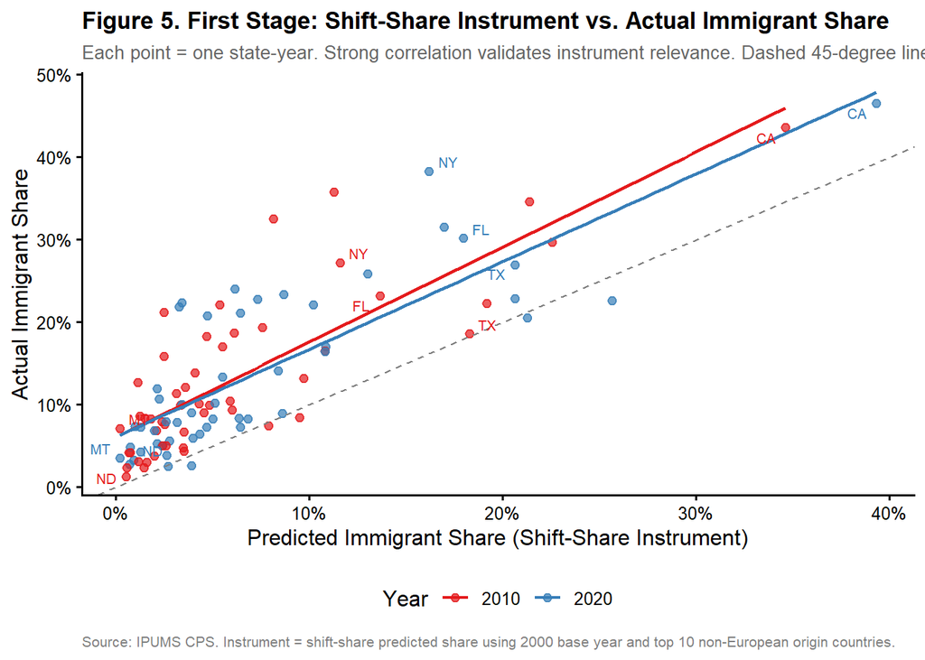

### Explanation of Figure 5

Figure 5 checks the **first stage** of the IV strategy. The horizontal axis shows the predicted immigrant share from the shift-share instrument, while the vertical axis shows the actual immigrant share. If the instrument is relevant, states with higher predicted immigrant shares should also tend to have higher actual immigrant shares.

The upward-sloping fitted lines indicate that the instrument is positively related to actual immigrant share. This supports the relevance condition for the IV approach. The dashed 45-degree line is a benchmark for perfect prediction; points do not need to lie exactly on this line, but a clear positive relationship is important. The graph therefore provides visual evidence that the instrument is informative, while the first-stage F-statistic provides the formal numerical check.

```
## Figure 6 saved.
```

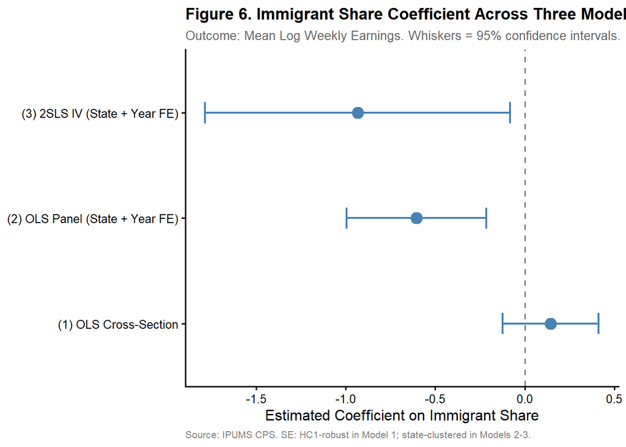

### Explanation of Figure 6

Figure 6 summarizes the immigrant-share coefficient from the three models. The dots are the estimated coefficients, and the horizontal whiskers are the 95 percent confidence intervals. The vertical dashed line at zero is the benchmark for no association.

If a confidence interval crosses zero, the estimate is not statistically distinguishable from zero at the 5 percent level. If the interval is fully to the left of zero, the estimate is statistically negative; if it is fully to the right, the estimate is statistically positive. In this figure, Model 1 is close to zero, while Models 2 and 3 move to the negative side. This visual pattern reinforces the table: the estimated relationship becomes more negative after adding fixed effects and using the IV strategy.

## Summary interpretation

**Model 1: OLS Cross-Section, 2020 only.** A 10 percentage-point higher immigrant share is associated with a 0.0144 change in mean log weekly wages. This is about 1.4 percent using the log-point approximation. This estimate is descriptive and not statistically significant in the regression output.

**Model 2: Panel OLS with state and year fixed effects.** Within a given state over time, a 10 percentage-point increase in immigrant share is associated with a -0.0605 change in mean log weekly wages. This is about -6.0 percent using the log-point approximation. This estimate is negative and statistically significant in the regression output.

**Model 3: 2SLS IV with state and year fixed effects.** Using variation in immigrant share predicted by historical settlement patterns and national origin-group growth, a 10 percentage-point increase in immigrant share is associated with a -0.0934 change in mean log weekly wages. This is about -9.3 percent using the log-point approximation. This estimate is negative and statistically significant in the regression output.